# MTH 530: Homework 4

Eric Stevens

November 29, 2018

## Question 1

### a)

**Data:**

```r
inter_n <- 73
major_n <- 105
minor_n <- 240
no_n <- 1080
inter_xbar <- 6.22
major_xbar <- 5.81
minor_xbar <- 5.77
no_xbar <- 5.47
inter_sd <- 1.62
major_sd <- 1.43
minor_sd <- 1.24
no_sd <- 1.31
```

**Get Overall Mean** In this case, the varying number of `n`s in each category results in the need to adjust the overall mean to be weighted by the number of `n`s. We can do this by multiplying our means in each category by their respective `n`, then sum these numbers, then divide by the total number of `n`s as follows.

```r
weighted_sum_of_means <- (inter_n*inter_xbar) +
  (major_n*major_xbar) +
  (minor_n*minor_xbar) +
  (no_n*no_xbar)
weighted_sum_of_means
```

```
[1] 8356.51
```

```r
sum_of_ns <- inter_n + major_n + minor_n + no_n
sum_of_ns
```

```
[1] 1498
```

```r
x_double_bar <- weighted_sum_of_means/sum_of_ns
x_double_bar
```

```
[1] 5.578445
```

**Sum Of Squares**

- Between Groups

```r
inter_BT <- ((inter_xbar-x_double_bar)^2)*(inter_n)
major_BT <- ((major_xbar-x_double_bar)^2)*(major_n)
minor_BT <- ((minor_xbar-x_double_bar)^2)*(minor_n)
no_BT <- ((no_xbar-x_double_bar)^2)*(no_n)
BT <- inter_BT + major_BT + minor_BT + no_BT
BT
```

```
[1] 57.18368
```

- Within

```r
inter_WI <- (inter_sd^2)*(inter_n-1)
major_WI <- (major_sd^2)*(major_n-1)
minor_WI <- (minor_sd^2)*(minor_n-1)
no_WI <- (no_sd^2)*(no_n-1)
WI <- inter_SSE + major_SSE + minor_SSE + no_SSE
WI
```

[output not shown]

- Total

```r
SST = BT + WI
SST
```

```
[1] 2677.968
```

**F Calculation**

```r
BToDF <- BT/(4-1)
WIoDF <- WI/(inter_n+major_n+minor_n+no_n-4)
F_value <- BToDF/WIoDF
BToDF
```

```
[1] 19.06123
```

```r
WIoDF
```

```
[1] 1.754207
```

```r
F_value
```

```
[1] 10.86601
```

| - | Sum of Squares | Degrees of Freedom | Mean Squared | F |
| --- | --- | --- | --- | --- |
| Total | 2677.968 | 1497 |  |  |
| Between | 57.18368 | 3 | 19.06123 | 10.86601 |
| Within | 2620.785 | 1494 | 1.754207 |  |

### b

**Get critical F value**

```r
qf(0.95, (4-1), inter_n+major_n+minor_n+no_n-4)
```

```
[1] 2.610859
```

Since our F value is over 10 and our and our critical F value is 2.6, we can reject the null. This means that two or more of our categories are statistically significantly different from one and other.

### c

- The initial data is normally distributed.
- Equal variance among groups.
- Samples are drawn independently of one and other.

### d

Yes, further analysis should be done to determine which mean or means have the statistically significant difference that is causing the F score allowing us to reject the null.

## Question 2

```r
library(tidyverse)
library(resampledata)
cuckoos <- Cuckoos
head(cuckoos)
```

|  | ID | Eggs | Bird |
| --- | --- | --- | --- |
| 1 | 1 | 19.65 | MeadowPipit |
| 2 | 2 | 20.05 | MeadowPipit |
| 3 | 3 | 20.65 | MeadowPipit |
| 4 | 4 | 20.85 | MeadowPipit |
| 5 | 5 | 21.65 | MeadowPipit |
| 6 | 6 | 21.65 | MeadowPipit |

### a

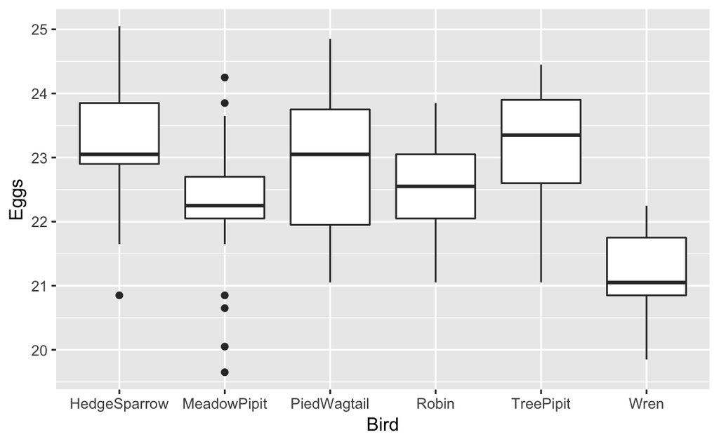

```r
cuckoos %>% group_by(Bird) %>%
  ggplot(aes(x=Bird, y=Eggs)) +
  geom_boxplot()
```

### b

```r
# Compute the analysis of variance
the_anova <- aov(Eggs~Bird, data = cuckoos)
# Summary of the analysis
summary(the_anova)
```

```
             Df Sum Sq Mean Sq F value   Pr(>F)
Bird          5  45.94   9.188   11.48 5.49e-09 ***
Residuals   114  91.25   0.800
---
Signif. codes:  0 ‘***’ 0.001 ‘**’ 0.01 ‘*’ 0.05 ‘.’ 0.1 ‘ ’ 1
```

### c

```r
TukeyHSD(the_anova)
```

```
  Tukey multiple comparisons of means
    95% family-wise confidence level

Fit: aov(formula = Eggs ~ Bird, data = cuckoos)

$Bird
                                diff        lwr         upr     p adj
MeadowPipit-HedgeSparrow -0.87142857 -1.6672254 -0.07563177 0.0231538
PiedWagtail-HedgeSparrow -0.21809524 -1.1818530  0.74566255 0.9862488
Robin-HedgeSparrow       -0.54642857 -1.4955355  0.40267841 0.5550394
TreePipit-HedgeSparrow    0.05357143 -0.8955355  1.00267841 0.9999833
Wren-HedgeSparrow        -1.99142857 -2.9551864 -1.02767078 0.0000004
PiedWagtail-MeadowPipit   0.65333333 -0.1220788  1.42874546 0.1506847
Robin-MeadowPipit         0.32500000 -0.4321254  1.08212545 0.8140113
TreePipit-MeadowPipit     0.92500000  0.1678746  1.68212545 0.0074440
Wren-MeadowPipit         -1.12000000 -1.8954121 -0.34458788 0.0007787
Robin-PiedWagtail        -0.32833333 -1.2604146  0.60374792 0.9099884
TreePipit-PiedWagtail     0.27166667 -0.6604146  1.20374792 0.9583313
Wren-PiedWagtail         -1.77333333 -2.7203288 -0.82633783 0.0000048
TreePipit-Robin           0.60000000 -0.3169245  1.51692445 0.4094264
Wren-Robin               -1.44500000 -2.3770813 -0.51291874 0.0002402
Wren-TreePipit           -2.04500000 -2.9770813 -1.11291874 0.0000001
```

### d

```r
TukeyHSD(the_anova, p.adjust(the_anova,method = "bonferroni"))
```

```
Error in p.adjust(the_anova, method = "bonferroni") :
  (list) object cannot be coerced to type 'double'
```

I cannot figure out how to do this.